# NFL 2020 Week 11

0.6000

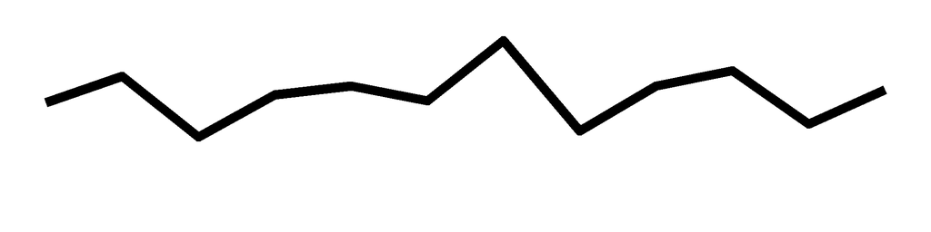

Kevin Quigley

8

8

9

10

10

8

8

6

8

7

9

10

0.6250

12

0.5771

0.5771

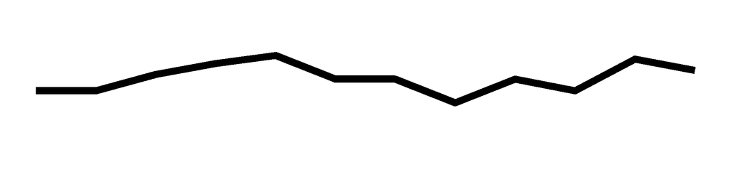

Eric Swenson

4

8

10

9

9

8

9

8

7

8

8

10

0.6250

12

0.5600

0.5600

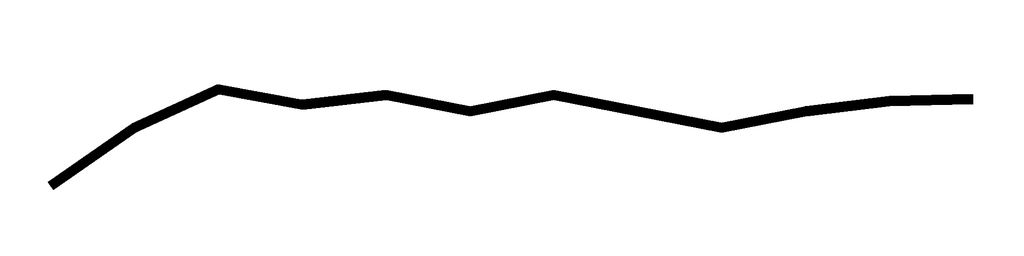

Tina Hartley

9

11

10

8

8

9

9

7

3

8

6

10

0.6250

12

0.5600

0.5600

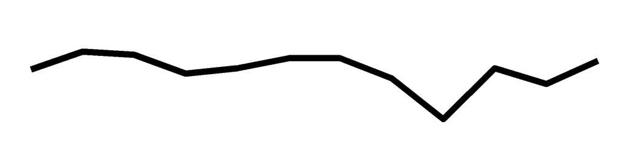

Josephine Cammack

9

11

12

10

9

9

11

7

6

8

NA

9

0.5625

11

0.6235

0.5715

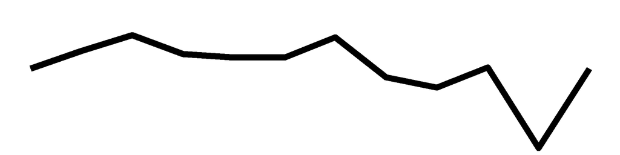

Blake Schwartz

10

9

10

10

10

9

9

6

5

8

7

9

0.5625

12

0.5829

0.5829

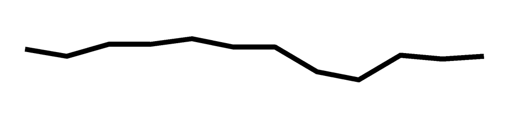

Margaret Wieczorek

11

14

9

9

8

NA

10

8

9

8

7

8

0.5000

11

0.6273

0.5750

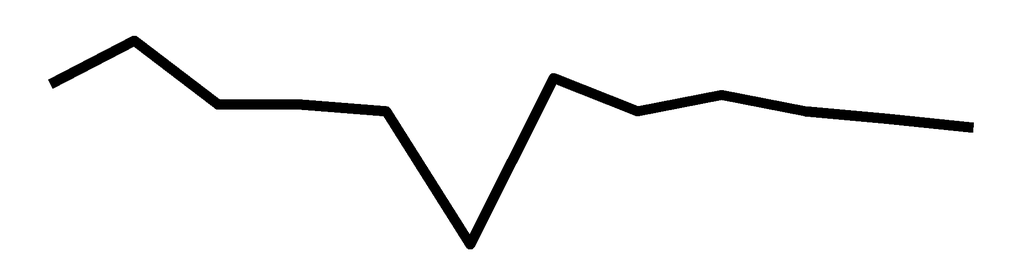

Daniel Richardson

13

11

10

10

8

NA

8

NA

NA

NA

NA

NA

0.0000

6

0.6667

0.3334

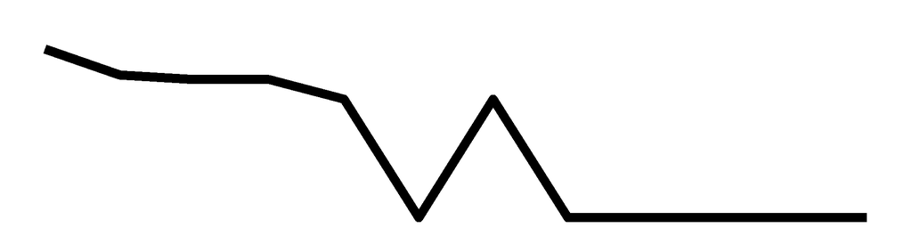

Travis Russell

11

8

8

11

10

10

10

8

NA

NA

7

NA

0.0000

9

0.6336

0.4752

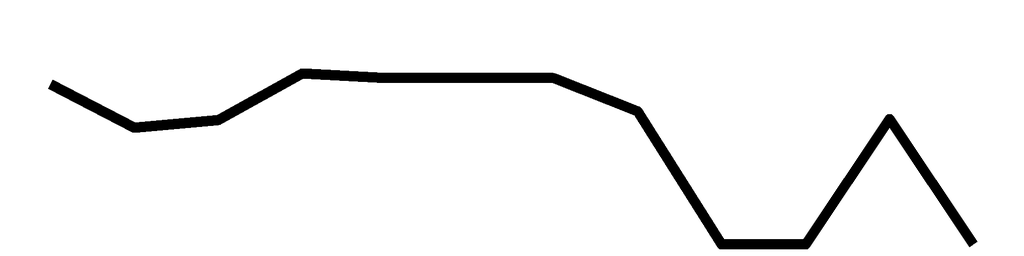

Gabriel Costa

9

12

6

9

10

7

9

7

10

10

9

NA

0.0000

11

0.6164

0.5650

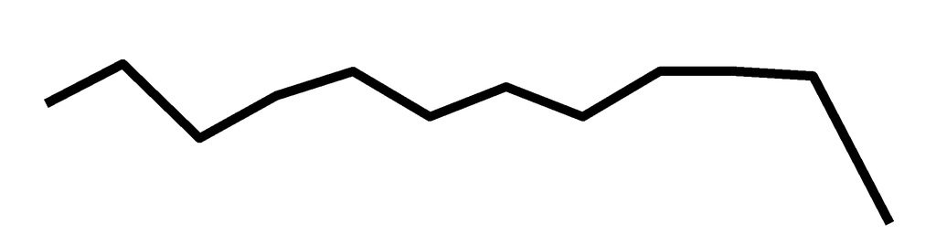

Welvin Lucero

9

11

9

10

NA

NA

11

8

NA

8

5

NA

0.0000

8

0.6068

0.4045

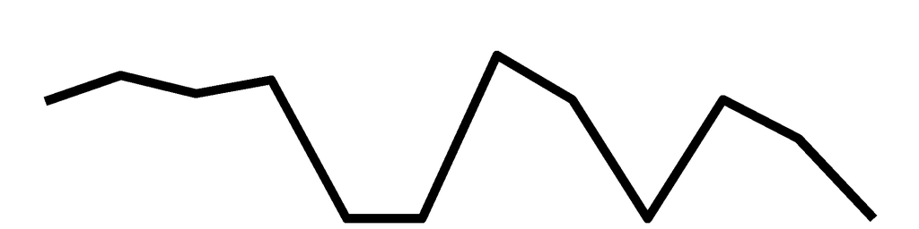

Andrew Lee

9

10

8

NA

NA

NA

NA

NA

NA

NA

NA

NA

0.0000

3

0.5745

0.1436

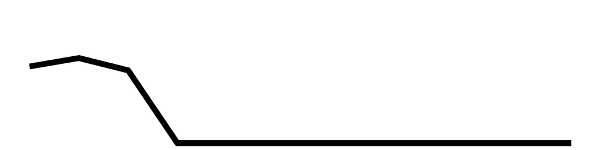

Timothy Moore

10

11

8

9

7

9

7

7

7

NA

NA

NA

0.0000

9

0.5682

0.4262

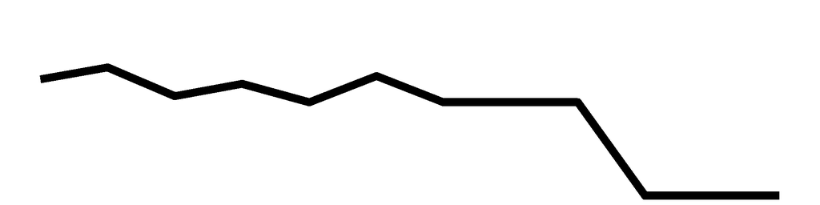

Congrats Nicholas Reisweber for having the best picks this week, with a correct percentage of 0.875

| Name | Week 1 | Week 2 | Week 3 | Week 4 | Week 5 | Week 6 | Week 7 | Week 8 | Week 9 | Week 10 | Week 11 | Week 12 | Percent | Weeks Picked | Season Percent | Adj Season Percent | Season Trend |
| --- | --- | --- | --- | --- | --- | --- | --- | --- | --- | --- | --- | --- | --- | --- | --- | --- | --- |
| Nicholas Reisweber | 9 | 10 | 10 | 8 | 10 | 7 | 8 | 8 | 10 | 9 | 6 | 14 | 0.8750 | 12 | 0.6229 | 0.6229 |  |
| Shane Clark | 10 | 14 | 9 | 9 | 9 | 9 | 10 | NA | 11 | 7 | 7 | 12 | 0.7500 | 11 | 0.6646 | 0.6092 |  |
| Kevin Cummiskey | 13 | 11 | 9 | 9 | 10 | 7 | 9 | 5 | 10 | 9 | 7 | 12 | 0.7500 | 12 | 0.6343 | 0.6343 |  |
| James Starling | 15 | 12 | 9 | 12 | 10 | NA | 11 | 8 | 10 | 10 | 6 | 11 | 0.6875 | 11 | 0.7081 | 0.6491 |  |
| Gregory Minetos | 9 | 14 | 10 | 12 | 8 | 8 | 12 | 7 | 10 | 7 | 7 | 11 | 0.6875 | 12 | 0.6571 | 0.6571 |  |
| Daniel Baller | 11 | 10 | 10 | 9 | 9 | 5 | 8 | 9 | 11 | 10 | 8 | 11 | 0.6875 | 12 | 0.6343 | 0.6343 |  |
| Frank Czerniakowski | 7 | 13 | 10 | 9 | 8 | 6 | 9 | 6 | 11 | 5 | 9 | 11 | 0.6875 | 12 | 0.5943 | 0.5943 |  |
| James Pleuss | 9 | 12 | 10 | 12 | 7 | 8 | 10 | 9 | 9 | 10 | 7 | 10 | 0.6250 | 12 | 0.6457 | 0.6457 |  |
| Michael Prokos | 9 | 12 | 9 | 8 | 11 | 10 | 9 | 7 | 9 | 9 | 7 | 10 | 0.6250 | 12 | 0.6286 | 0.6286 |  |
| John Kearby | 9 | 11 | 6 | 9 | 9 | 8 | 12 | 6 | 9 | 10 | 6 | 10 | 0.6250 | 12 | 0.6 | 0.6 |  |
| Kevin Quigley | 8 | 8 | 9 | 10 | 10 | 8 | 8 | 6 | 8 | 7 | 9 | 10 | 0.6250 | 12 | 0.5771 | 0.5771 |  |
| Eric Swenson | 4 | 8 | 10 | 9 | 9 | 8 | 9 | 8 | 7 | 8 | 8 | 10 | 0.6250 | 12 | 0.56 | 0.56 |  |
| Tina Hartley | 9 | 11 | 10 | 8 | 8 | 9 | 9 | 7 | 3 | 8 | 6 | 10 | 0.6250 | 12 | 0.56 | 0.56 |  |
| Josephine Cammack | 9 | 11 | 12 | 10 | 9 | 9 | 11 | 7 | 6 | 8 | NA | 9 | 0.5625 | 11 | 0.6235 | 0.5715 |  |
| Blake Schwartz | 10 | 9 | 10 | 10 | 10 | 9 | 9 | 6 | 5 | 8 | 7 | 9 | 0.5625 | 12 | 0.5829 | 0.5829 |  |
| Margaret Wieczorek | 11 | 14 | 9 | 9 | 8 | NA | 10 | 8 | 9 | 8 | 7 | 8 | 0.5000 | 11 | 0.6273 | 0.575 |  |
| Daniel Richardson | 13 | 11 | 10 | 10 | 8 | NA | 8 | NA | NA | NA | NA | NA | 0.0000 | 6 | 0.6667 | 0.3334 |  |
| Travis Russell | 11 | 8 | 8 | 11 | 10 | 10 | 10 | 8 | NA | NA | 7 | NA | 0.0000 | 9 | 0.6336 | 0.4752 |  |
| Gabriel Costa | 9 | 12 | 6 | 9 | 10 | 7 | 9 | 7 | 10 | 10 | 9 | NA | 0.0000 | 11 | 0.6164 | 0.565 |  |
| Welvin Lucero | 9 | 11 | 9 | 10 | NA | NA | 11 | 8 | NA | 8 | 5 | NA | 0.0000 | 8 | 0.6068 | 0.4045 |  |
| Andrew Lee | 9 | 10 | 8 | NA | NA | NA | NA | NA | NA | NA | NA | NA | 0.0000 | 3 | 0.5745 | 0.1436 |  |
| Timothy Moore | 10 | 11 | 8 | 9 | 7 | 9 | 7 | 7 | 7 | NA | NA | NA | 0.0000 | 9 | 0.5682 | 0.4262 |  |

[figure not shown]

```r
improvement_formatter <-
  formatter("span",
            style = x ~ style(
              font.weight = "bold",
              color = ifelse(x > .5, "green", ifelse(x < .5, "red", "black"))),
             x ~ icontext(ifelse(x == max(x), "star", ""), x))

indiv_disp_3 = indiv_disp_2 %>% select(-plot)
indiv_disp_3$`Season Trend` = apply(indiv_disp_3[,2:(1+length(weeks))], 1, FUN = function(x) as.character(htmltools::as.tags(sparkline(as.numeric(x), type = "line", chartRangeMin = 0, chartRangeMax = 1, fillColor = "white"))))

out = as.htmlwidget(formattable(indiv_disp_3,
                                align = c("l", rep("c", NROW(indiv_disp_3)-1)),
              list(`Season Percent` = color_bar("#FA614B"),
              `Season Percent`= improvement_formatter,
              `Adj Season Percent`= improvement_formatter)))

out$dependencies = c(out$dependencies, htmlwidgets:::widget_dependencies("sparkline", "sparkline"))

out
```

## MA206 Group Predictions

This Week's MA206 Predictions

Week 12

| Game | Prediction | Winner | Correct | Correct Votes | Correct Percent |
| --- | --- | --- | --- | --- | --- |
| 1 | Houston Texans | Houston Texans | Yes | 7 | 0.5833 |
| 2 | Dallas Cowboys | Washington Football Team | No | 5 | 0.4167 |
| 3 | Las Vegas Raiders | Atlanta Falcons | No | 1 | 0.0833 |
| 4 | Buffalo Bills | Buffalo Bills | Yes | 10 | 0.8333 |
| 5 | Miami Dolphins | Miami Dolphins | Yes | 11 | 0.9167 |
| 6 | Tennessee Titans | Tennessee Titans | Yes | 8 | 0.6667 |
| 7 | Cleveland Browns | Cleveland Browns | Yes | 11 | 0.9167 |
| 8 | New York Giants | New York Giants | Yes | 10 | 0.8333 |
| 9 | Minnesota Vikings | Minnesota Vikings | Yes | 7 | 0.5833 |
| 10 | Arizona Cardinals | New England Patriots | No | 1 | 0.0833 |
| 11 | Los Angeles Rams | San Francisco 49ers | No | 2 | 0.1667 |
| 12 | New Orleans Saints | New Orleans Saints | Yes | 11 | 0.9167 |
| 13 | Kansas City Chiefs | Kansas City Chiefs | Yes | 11 | 0.9167 |
| 14 | Green Bay Packers | Green Bay Packers | Yes | 9 | 0.7500 |
| 15 | Seattle Seahawks | Seattle Seahawks | Yes | 11 | 0.9167 |
| 16 | Pittsburgh Steelers | Pittsburgh Steelers | Yes | 8 | 0.6667 |

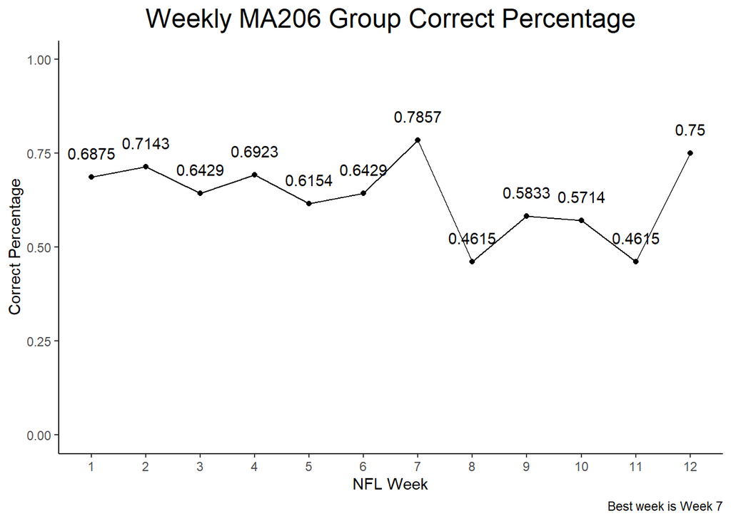

# Cadet Individual Results

MA206 Individual Results

Week 12

Name

Weekly # Correct

Percent

Weeks Picked

Season Percent

Adj Season Percent

Season Trend

Week 1

Week 2

Week 3

Week 4

Week 5

Week 6

Week 7

Week 8

Week 9

Week 10

Week 11

Week 12

Jonathan Kemp

10

10

NA

NA

11

10

11

7

8

6

8

12

0.7500

10

0.6414

0.5345

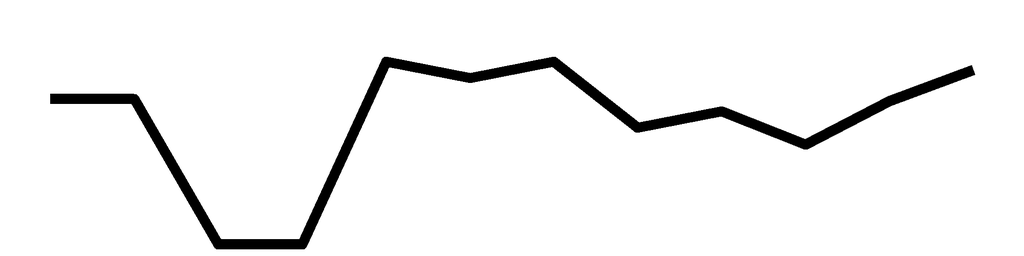

Thomas Bizub

10

14

8

11

8

9

10

8

10

12

9

11

0.6875

12

0.6857

0.6857

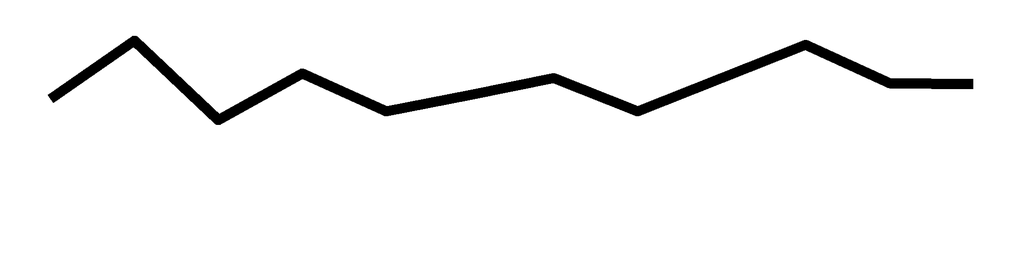

Victor Olawale-Apanpa

8

NA

10

NA

10

NA

10

7

7

9

6

11

0.6875

9

0.6000

0.4500

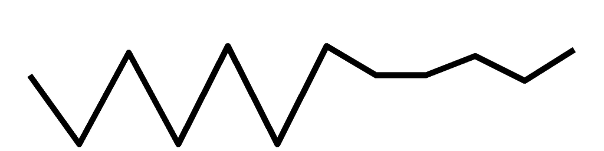

John White

10

11

10

8

12

9

11

6

9

9

8

10

0.6250

12

0.6457

0.6457

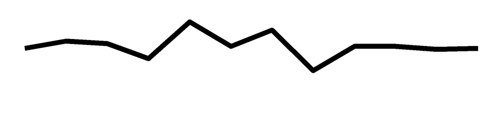

Christopher Erb

9

9

7

11

9

11

8

11

10

9

5

10

0.6250

12

0.6229

0.6229

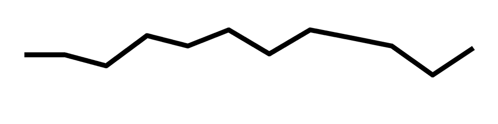

Zakai Bufkin

8

11

7

9

8

10

9

7

9

9

NA

10

0.6250

11

0.5988

0.5489

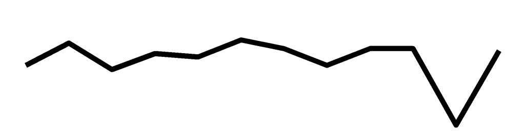

Sidney Cash

10

10

NA

10

NA

8

8

7

11

8

5

10

0.6250

10

0.5959

0.4966

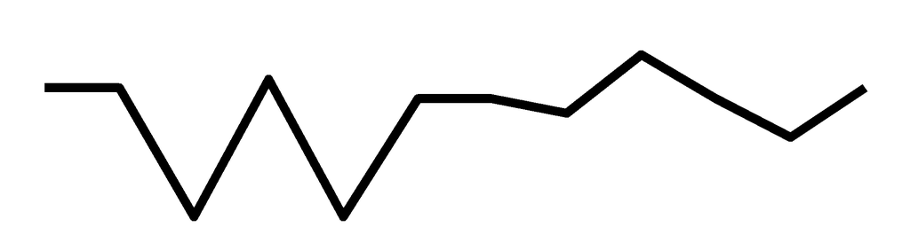

Joshua Loyd

11

9

8

NA

6

9

NA

6

10

8

NA

10

0.6250

9

0.5789